# Week 5

# The Battle of Neighborhoods

## Description of the problem

A description of the problem and a discussion of the background.

- The Housing & Development Board (HDB) is Singapore's public housing authority and a statutory board under the Ministry of National Development. They develop public housing to provide Singaporeans with affordable, quality homes, and a better living environment. Focusing on nurturing a strong family and community spirit, public housing policies and schemes are formulated to meet changing needs and aspirations. Foreigners who gained Permanent Residency are allowed to purchase HDB housing through resale. In this project, we are targeting to develop a machine learning model to predit the resale price of HDB housing.

## Audience

- The project is designed for Singaporean/Permanent Resiedents(PR) to predict the resale price of their prospect HDB housing. The result serve as guidance for pricing.

## Methodology

- this is a regression model with features of HDB housing by type,age, commercial, facilities and location data, with target as resale price

# Data

## Sources

1. Government Data API: data.gov.sg
   - HDB property info: https://data.gov.sg/dataset/hdb-property-information
   - HDB median rental by town by flat type: https://data.gov.sg/dataset/median-rent-by-town-and-flat-type
   - Median Resale price by town by flat type: https://data.gov.sg/dataset/median-resale-prices-for-registered-applications-by-town-and-flat-type
2. Singapore official geocoding data through OneMap API: http://developers.onemap.sg/commonapi/

Note: Foursquare API is slower and less reliable than official OneMap API, which also gives geocoding and relevant info for Singapore locations. Hence in this project, we will replace Foursquare API with OneMap API

## Schema

```
    Name: 'blk_no'
    Title: 'Block number'
    Type: 'text'
    Sub Type: 'general'
  -
    Name: 'street'
    Title: 'Street'
    Type: 'text'
    Sub Type: 'general'
  -
    Name: 'max_floor_lvl'
    Title: 'Maximum floor level'
    Type: 'numeric'
    Sub Type: 'general'
    Unit Of Measure: 'No. of storeys'
  -
    Name: 'year_completed'
    Title: 'Year completed'
    Type: 'datetime'
    Sub Type: 'year'
    Format: 'YYYY'
  -
    Name: 'residential'
    Title: 'Residential property tag'
    Type: 'text'
    Sub Type: 'general'
  -
    Name: 'commercial'
    Title: 'Commercial property tag'
    Type: 'text'
    Sub Type: 'general'
  -
    Name: 'market_hawker'
    Title: 'Market and hawker tag'
    Type: 'text'
    Sub Type: 'general'
  -
    Name: 'miscellaneous'
    Title: 'Miscellaneous'
    Type: 'text'
    Sub Type: 'general'
    Description: 'Examples include admin office, childcare centre, education centre,
      Residents'' Committees centre'
  -
    Name: 'multistorey_carpark'
    Title: 'Multi-storey carpark tag'
    Type: 'text'
    Sub Type: 'general'
  -
    Name: 'precinct_pavilion'
    Title: 'Precinct pavilion tag'
    Type: 'text'
    Sub Type: 'general'
  -
    Name: 'bldg_contract_town'
    Title: 'Town'
    Type: 'text'
    Sub Type: 'general'
    Description:
      - 'Legend:'
      - 'AMK - ANG MO KIO'
      - 'BB - BUKIT BATOK'
      - 'BD - BEDOK'
      - 'BH - BISHAN'
      - 'BM - BUKIT MERAH'
      - 'BP - BUKIT PANJANG'
      - 'BT - BUKIT TIMAH'
      - 'CCK - CHOA CHU KANG'
      - 'CL - CLEMENTI'
      - 'CT - CENTRAL AREA'
      - 'GL - GEYLANG'
      - 'HG - HOUGANG'
      - 'JE - JURONG EAST'
      - 'JW - JURONG WEST'
      - 'KWN - KALLANG/WHAMPOA'
      - 'MP - MARINE PARADE'
      - 'PG - PUNGGOL'
      - 'PRC - PASIR RIS'
      - 'QT - QUEENSTOWN'
      - 'SB - SEMBAWANG'
      - 'SGN - SERANGOON'
      - 'SK - SENGKANG'
      - 'TAP - TAMPINES'
      - 'TG - TENGAH'
      - 'TP - TOA PAYOH'
      - 'WL - WOODLANDS'
      - 'YS - YISHUN'
  -
    Name: 'total_dwelling_units'
    Title: 'Total dwelling units'
    Type: 'numeric'
    Sub Type: 'general'
    Unit Of Measure: 'No. of units'
  -
    Name: '1room_sold'
    Title: 'Number of 1-room sold flats'
    Type: 'numeric'
    Sub Type: 'general'
    Unit Of Measure: 'No. of units'
  -
    Name: '2room_sold'
    Title: 'Number of 2-room sold flats'
    Type: 'numeric'
    Sub Type: 'general'
    Unit Of Measure: 'No. of units'
  -
    Name: '3room_sold'
    Title: 'Number of 3-room sold flats'
    Type: 'numeric'
    Sub Type: 'general'
    Unit Of Measure: 'No. of units'
  -
    Name: '4room_sold'
    Title: 'Number of 4-room sold flats'
    Type: 'numeric'
    Sub Type: 'general'
    Unit Of Measure: 'No. of units'
  -
    Name: '5room_sold'
    Title: 'Number of 5-room sold flats'
    Type: 'numeric'
    Sub Type: 'general'
    Unit Of Measure: 'No. of units'
  -
    Name: 'exec_sold'
    Title: 'Number of Executive sold flats'
    Type: 'numeric'
    Sub Type: 'general'
    Unit Of Measure: 'No. of units'
  -
    Name: 'multigen_sold'
    Title: 'Number of Multi-generation sold flats'
    Type: 'numeric'
    Sub Type: 'general'
    Unit Of Measure: 'No. of units'
  -
    Name: 'studio_apartment_sold'
    Title: 'Number of Studio apartment sold flats'
    Type: 'numeric'
    Sub Type: 'general'
    Unit Of Measure: 'No. of units'
  -
    Name: '1room_rental'
    Title: 'Number of 1-room rental flats'
    Type: 'numeric'
    Sub Type: 'general'
    Unit Of Measure: 'No. of units'
  -
    Name: '2room_rental'
    Title: 'Number of 2-room rental flats'
    Type: 'numeric'
    Sub Type: 'general'
    Unit Of Measure: 'No. of units'
  -
    Name: '3room_rental'
    Title: 'Number of 3-room rental flats'
    Type: 'numeric'
    Sub Type: 'general'
    Unit Of Measure: 'No. of units'
  -
    Name: 'other_room_rental'
    Title: 'Number of Other room rental flats'
    Type: 'numeric'
    Sub Type: 'general'
    Unit Of Measure: 'No. of units'
   -
    Name: 'quarter'
    Title: 'Quarter'
    Type: 'datetime'
    Sub Type: 'quarter'
    Format: 'YYYY-[Q]Q'
  -
    Name: 'town'
    Title: 'Town'
    Type: 'text'
    Sub Type: 'general'
  -
    Name: 'flat_type'
    Title: 'Flat Type'
    Type: 'text'
    Sub Type: 'general'
  -
    Name: 'median_rent'
    Title: 'Median rent'
    Type: 'text'
    Sub Type: 'general'
    Description:
      - '"na" : Data not available or not applicable'
      - '"-" : Data is negligible or not significant'

    -
    Name: 'price'
    Title: 'Median Resale Price'
    Type: 'text'
    Sub Type: 'general'
    Description:
      - '"na" : Data not available or not applicable'
      - '"-" : Data is negligible or not significant'
```

# Code

```python
import numpy as np
import pandas as pd
```

- Reading csv from Governement Database mentioned in Data sources section

```python
rent=pd.read_csv('median-rent-by-town-and-flat-type.csv')
hdb=pd.read_csv('hdb-property-information.csv')
resale=pd.read_csv('median-resale-prices-for-registered-applications-by-town-and-flat-type.csv')
```

- Transform year of completion to age and address by combining block_no and street
- Map town code to town's full name

```python
hdb['age']=2019-hdb.year_completed
hdb['address']=hdb.blk_no+' '+hdb.street
hdb['town']=hdb.bldg_contract_town.map({'TAP':'TAMPINES','JW':'JURONG WEST','WL':'WOODLANDS',\
                                        'SK':'SENGKANG','YS':'YISHUN','HG':'HOUGANG',\
                                        'CCK':'CHOA CHU KANG','PG':'PUNGGOL','BD':'BEDOK',\
                                       'BM':'BUKIT MERAH','PRC':'PASIR RIS','BB':'BUKIT BATOK','AMK':'ANG MO KIO',\
                                       'BP':'BUKIT PANJANG','KWN':'KALLANG/WHAMPOA','TP':'TOA PAYOH',\
                                       'GL':'GEYLANG','SB':'SEMBAWANG','QT':'QUEENSTOWN','BH':'BISHAN',\
                                       'JE':'JURONG EAST','SGN':'SERANGOON','CL':'CLEMENTI',\
                                        'CT':'CENTRAL','MP':'MARINE PARADE','BT':'BUKIT TIMAH'})
```

- Encoding the Binary feature of Y/N to Boolean, 1 for Yes and 0 for No

```python
hdb[['residential','commercial','market_hawker','miscellaneous','multistorey_carpark','precinct_pavilion']]=hdb[['residential','commercial','market_hawker','miscellaneous','multistorey_carpark','precinct_pavilion']].apply(lambda x:x.map({'Y':1,'N':0}))
```

```python
hdb.head()
```

|  | blk_no | street | max_floor_lvl | year_completed | residential | commercial | market_hawker | miscellaneous | multistorey_carpark | precinct_pavilion | ... | exec_sold | multigen_sold | studio_apartment_sold | 1room_rental | 2room_rental | 3room_rental | other_room_rental | age | address | town |
| --- | --- | --- | --- | --- | --- | --- | --- | --- | --- | --- | --- | --- | --- | --- | --- | --- | --- | --- | --- | --- | --- |
| 0 | 1 | BEACH RD | 16 | 1970 | 1 | 1 | 0 | 0 | 0 | 0 | ... | 0 | 0 | 0 | 0 | 0 | 0 | 0 | 49 | 1 BEACH RD | KALLANG/WHAMPOA |
| 1 | 1 | BEDOK STH AVE 1 | 14 | 1975 | 1 | 0 | 0 | 1 | 0 | 0 | ... | 0 | 0 | 0 | 0 | 0 | 0 | 0 | 44 | 1 BEDOK STH AVE 1 | BEDOK |
| 2 | 1 | CANTONMENT RD | 2 | 2010 | 0 | 1 | 0 | 0 | 0 | 0 | ... | 0 | 0 | 0 | 0 | 0 | 0 | 0 | 9 | 1 CANTONMENT RD | CENTRAL |
| 3 | 1 | CHAI CHEE RD | 15 | 1982 | 1 | 0 | 0 | 0 | 0 | 0 | ... | 0 | 0 | 0 | 0 | 0 | 0 | 0 | 37 | 1 CHAI CHEE RD | BEDOK |
| 4 | 1 | CHANGI VILLAGE RD | 4 | 1975 | 1 | 1 | 0 | 0 | 0 | 0 | ... | 0 | 0 | 0 | 0 | 0 | 0 | 0 | 44 | 1 CHANGI VILLAGE RD | PASIR RIS |

5 rows × 27 columns

```python
hdb_df=hdb[['max_floor_lvl','residential','commercial','market_hawker',
            'miscellaneous','multistorey_carpark',
           'precinct_pavilion', 'total_dwelling_units',
           '1room_sold', '2room_sold', '3room_sold', '4room_sold', '5room_sold',
           'exec_sold', 'multigen_sold', 'studio_apartment_sold', '1room_rental',
           '2room_rental', '3room_rental', 'other_room_rental', 'age', 'address',
           'town']]
```

- Take recent rental and resale data of 2019-Q3

```python
Q3_rent=rent[rent['quarter']=='2019-Q3']
```

```python
Q3_rent=Q3_rent[~Q3_rent['median_rent'].isin(['na','-'])]
```

```python
Q3_resale=resale[resale['quarter']=='2019-Q3']
```

```python
Q3_resale.flat_type.value_counts()
```

```
3-ROOM    26
1-ROOM    26
EXEC      26
2-ROOM    26
4-ROOM    26
5-ROOM    26
Name: flat_type, dtype: int64
```

- Map the flat types to match among various data sources

```python
Q3_resale.flat_type=Q3_resale.flat_type.map({'1-ROOM':'1-RM','2-ROOM':'2-RM','3-ROOM':'3-RM','4-ROOM':'4-RM','5-ROOM':'5-RM'})
```

```python
Q3_value=Q3_rent.merge(Q3_resale,how='left',left_on=['quarter','town','flat_type'],right_on=['quarter','town','flat_type'])
```

```python
Q3_value.head()
```

|  | quarter | town | flat_type | median_rent | price |
| --- | --- | --- | --- | --- | --- |
| 0 | 2019-Q3 | ANG MO KIO | 3-RM | 1700 | 280000 |
| 1 | 2019-Q3 | ANG MO KIO | 4-RM | 2100 | 408000 |
| 2 | 2019-Q3 | ANG MO KIO | 5-RM | 2400 | 597500 |
| 3 | 2019-Q3 | BEDOK | 3-RM | 1700 | 280000 |
| 4 | 2019-Q3 | BEDOK | 4-RM | 2000 | 400000 |

```python
hdb_df=hdb_df.merge(Q3_value,how='outer',on=['town'])
```

```python
addlist=hdb.address #Address list to call OneMap API and GET geocoding info
```

```python
import requests
import json
import re
import time
from tqdm import tqdm
from random import randint
```

```python
# -*- coding: utf-8 -*-
user_agents =['Mozilla/5.0 (Windows NT 10.0; Win64; x64) AppleWebKit/537.36 (KHTML, like Gecko) Chrome/74.0.3729.169 Safari/537.36',\
              'Mozilla/5.0 (Windows NT 10.0; Win64; x64) AppleWebKit/537.36 (KHTML, like Gecko) Chrome/74.0.3729.157 Safari/537.36',\
             'Mozilla/5.0 (Windows NT 10.0; Win64; x64) AppleWebKit/537.36 (KHTML, like Gecko) Chrome/64.0.3282.140 Safari/537.36 Edge/18.17763',\
             'Mozilla/5.0 (Windows NT 10.0; Win64; x64) AppleWebKit/537.36 (KHTML, like Gecko) Chrome/58.0.3029.110 Safari/537.36 Edge/16.16299',\
             'Mozilla/5.0 (Macintosh; Intel Mac OS X 10_10_5) AppleWebKit/603.3.8 (KHTML, like Gecko) Version/10.1.2 Safari/603.3.8',\
             'Mozilla/5.0 (Macintosh; Intel Mac OS X 10_11_6) AppleWebKit/601.7.8 (KHTML, like Gecko)',\
             'Mozilla/5.0 (Macintosh; Intel Mac OS X 10_11_6) AppleWebKit/605.1.15 (KHTML, like Gecko) Version/11.1.2 Safari/605.1.15',\
             'Mozilla/5.0 (Macintosh; Intel Mac OS X 10_10_5) AppleWebKit/600.8.9 (KHTML, like Gecko)',\
             'Mozilla/5.0 (Macintosh; Intel Mac OS X 10_6_8) AppleWebKit/537.36 (KHTML, like Gecko) Chrome/49.0.2623.112 Safari/537.36',\
             'Mozilla/5.0 (X11; Ubuntu; Linux x86_64; rv:15.0) Gecko/20100101 Firefox/15.0.1']

#get agents from: https://developers.whatismybrowser.com/
```

- API to GET Geocoding

```python
LAT=[]
LON=[]
Address=[]
for i in tqdm(range(len(addlist))):

    try:
        index = randint(0, 9)
        user_agent = user_agents[index]
        headers = {'User-Agent': user_agent}
        response=requests.get('http://developers.onemap.sg/commonapi/search?searchVal={0}&returnGeom=Y&getAddrDetails=N&pageNum={1}'\
                          .format(addlist[i], 1),headers=headers).json()
        Address.append(addlist[i])
        LAT.append(response['results'][0]['LATITUDE'])
        LON.append(response['results'][0]['LONGITUDE'])

    except (RuntimeError, TypeError, NameError,IndexError):
        Address.append(addlist[i])
        LAT.append(None)
        LON.append(None)

    time.sleep(0.5)
```

```python
Coordinate=pd.DataFrame(list(zip(Address,LAT,LON)),columns=['address','Latitude','Longitude'])
```

```python
Coordinate.to_csv('Coordinate.csv') #Save results
```

```python
Coordinate=pd.read_csv('Coordinate.csv') #Read results
```

```python
Coordinate=Coordinate.drop(['Unnamed: 0'],axis=1)
```

```python
Coordinate.isnull().any()
```

```
Address      False
Latitude      True
Longitude     True
dtype: bool
```

- Not all address found

```python
hdb_data=hdb_df.merge(Coordinate,how='inner',left_on='address',right_on='Address')
```

```python
hdb_data.drop(['quarter'],axis=1,inplace=True)
hdb_data.columns
```

```
Index(['max_floor_lvl', 'residential', 'commercial', 'market_hawker',
       'miscellaneous', 'multistorey_carpark', 'precinct_pavilion',
       'total_dwelling_units', '1room_sold', '2room_sold', '3room_sold',
       '4room_sold', '5room_sold', 'exec_sold', 'multigen_sold',
       'studio_apartment_sold', '1room_rental', '2room_rental', '3room_rental',
       'other_room_rental', 'age', 'address', 'town', 'flat_type',
       'median_rent', 'price', 'Address', 'Latitude', 'Longitude'],
      dtype='object')
```

```python
hdb_data['Address'].isnull().value_counts()
```

```
False    43857
Name: Address, dtype: int64
```

- All inner joined remain 43857 units

```python
hdb_data.drop(['Address'],axis=1,inplace=True)
hdb_data.columns
```

```
Index(['max_floor_lvl', 'residential', 'commercial', 'market_hawker',
       'miscellaneous', 'multistorey_carpark', 'precinct_pavilion',
       'total_dwelling_units', '1room_sold', '2room_sold', '3room_sold',
       '4room_sold', '5room_sold', 'exec_sold', 'multigen_sold',
       'studio_apartment_sold', '1room_rental', '2room_rental', '3room_rental',
       'other_room_rental', 'age', 'address', 'town', 'flat_type',
       'median_rent', 'price', 'Latitude', 'Longitude'],
      dtype='object')
```

```python
hdb_data.info()
```

```
<class 'pandas.core.frame.DataFrame'>
Int64Index: 43857 entries, 0 to 43856
Data columns (total 28 columns):
max_floor_lvl            43857 non-null int64
residential              43857 non-null int64
commercial               43857 non-null int64
market_hawker            43857 non-null int64
miscellaneous            43857 non-null int64
multistorey_carpark      43857 non-null int64
precinct_pavilion        43857 non-null int64
total_dwelling_units     43857 non-null int64
1room_sold               43857 non-null int64
2room_sold               43857 non-null int64
3room_sold               43857 non-null int64
4room_sold               43857 non-null int64
5room_sold               43857 non-null int64
exec_sold                43857 non-null int64
multigen_sold            43857 non-null int64
studio_apartment_sold    43857 non-null int64
1room_rental             43857 non-null int64
2room_rental             43857 non-null int64
3room_rental             43857 non-null int64
other_room_rental        43857 non-null int64
age                      43857 non-null int64
address                  43857 non-null object
town                     43857 non-null object
flat_type                43811 non-null object
median_rent              43811 non-null object
price                    35585 non-null object
Latitude                 43021 non-null float64
Longitude                43021 non-null float64
dtypes: float64(2), int64(21), object(5)
memory usage: 8.9+ MB
```

```python
hdb_data['flat_type'].value_counts()
```

```
4-RM    12154
5-RM    12037
3-RM    11288
EXEC     7992
2-RM      340
Name: flat_type, dtype: int64
```

- Flat Types are numeric feature that will affect price, hence transform string to Categorical

```python
hdb_data['flat_type']=hdb_data['flat_type'].map({'EXEC':1,'2-RM':2,'3-RM':3,'4-RM':4,'5-RM':5})
```

```python
hdb_data['median_rent']=pd.to_numeric(hdb_data['median_rent'])
```

```python
hdb_data['price']=pd.to_numeric(hdb_data['price'],errors='coerce')
```

```python
data_set=hdb_data[~(hdb_data['price'].isnull())] # Data set to train and test
```

```python
to_explore=hdb_data[hdb_data['price'].isnull()] # Data set to explore
```

```python
data_set.describe() # Overview of Data set
```

|  | max_floor_lvl | residential | commercial | market_hawker | miscellaneous | multistorey_carpark | precinct_pavilion | total_dwelling_units | 1room_sold | 2room_sold | ... | 1room_rental | 2room_rental | 3room_rental | other_room_rental | age | flat_type | median_rent | price | Latitude | Longitude |
| --- | --- | --- | --- | --- | --- | --- | --- | --- | --- | --- | --- | --- | --- | --- | --- | --- | --- | --- | --- | --- | --- |
| count | 34554.000000 | 34554.000000 | 34554.000000 | 34554.000000 | 34554.000000 | 34554.000000 | 34554.000000 | 34554.000000 | 34554.000000 | 34554.000000 | ... | 34554.000000 | 34554.000000 | 34554.00000 | 34554.000000 | 34554.000000 | 34554.000000 | 34554.000000 | 34554.000000 | 33891.000000 | 33891.000000 |
| mean | 11.967240 | 0.822683 | 0.207357 | 0.008798 | 0.224055 | 0.081380 | 0.058430 | 88.418938 | 0.044279 | 1.962349 | ... | 2.714707 | 2.507785 | 0.11932 | 0.008769 | 26.070035 | 4.023673 | 1953.887538 | 422948.671644 | 1.366290 | 103.840188 |
| std | 6.888659 | 0.381942 | 0.405419 | 0.093385 | 0.416965 | 0.273422 | 0.234559 | 66.183893 | 3.359969 | 12.343498 | ... | 26.631856 | 21.581439 | 2.78184 | 0.517132 | 13.727770 | 0.808434 | 311.021615 | 136138.463521 | 0.042256 | 0.073595 |
| min | 1.000000 | 0.000000 | 0.000000 | 0.000000 | 0.000000 | 0.000000 | 0.000000 | 0.000000 | 0.000000 | 0.000000 | ... | 0.000000 | 0.000000 | 0.00000 | 0.000000 | 0.000000 | 3.000000 | 1400.000000 | 239500.000000 | 1.270380 | 103.685228 |
| 25% | 6.000000 | 1.000000 | 0.000000 | 0.000000 | 0.000000 | 0.000000 | 0.000000 | 39.000000 | 0.000000 | 0.000000 | ... | 0.000000 | 0.000000 | 0.00000 | 0.000000 | 18.000000 | 3.000000 | 1750.000000 | 330000.000000 | 1.337865 | 103.774574 |
| 50% | 12.000000 | 1.000000 | 0.000000 | 0.000000 | 0.000000 | 0.000000 | 0.000000 | 91.000000 | 0.000000 | 0.000000 | ... | 0.000000 | 0.000000 | 0.00000 | 0.000000 | 26.000000 | 4.000000 | 1900.000000 | 406000.000000 | 1.364542 | 103.845414 |
| 75% | 16.000000 | 1.000000 | 0.000000 | 0.000000 | 0.000000 | 0.000000 | 0.000000 | 120.000000 | 0.000000 | 0.000000 | ... | 0.000000 | 0.000000 | 0.00000 | 0.000000 | 35.000000 | 5.000000 | 2100.000000 | 487500.000000 | 1.392941 | 103.899025 |
| max | 47.000000 | 1.000000 | 1.000000 | 1.000000 | 1.000000 | 1.000000 | 1.000000 | 584.000000 | 255.000000 | 225.000000 | ... | 520.000000 | 452.000000 | 114.00000 | 32.000000 | 82.000000 | 5.000000 | 2800.000000 | 832500.000000 | 1.457071 | 103.988299 |

8 rows × 26 columns

```python
import seaborn as sns
import matplotlib.pyplot as plt
```

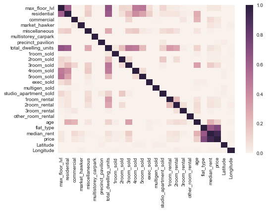

```python
ax = sns.heatmap(data_set.corr(), vmin=0, vmax=1)

plt.show()
```

- Based on heatmap of correlation, Price is affected mostly by Rent and type, coming with age which is slightly correlated toprice.

```python
data_set.columns
```

```
Index(['max_floor_lvl', 'residential', 'commercial', 'market_hawker',
       'miscellaneous', 'multistorey_carpark', 'precinct_pavilion',
       'total_dwelling_units', '1room_sold', '2room_sold', '3room_sold',
       '4room_sold', '5room_sold', 'exec_sold', 'multigen_sold',
       'studio_apartment_sold', '1room_rental', '2room_rental', '3room_rental',
       'other_room_rental', 'age', 'address', 'town', 'flat_type',
       'median_rent', 'price', 'Latitude', 'Longitude'],
      dtype='object')
```

```python
data_set.info()
```

```
<class 'pandas.core.frame.DataFrame'>
Int64Index: 34554 entries, 0 to 43855
Data columns (total 28 columns):
max_floor_lvl            34554 non-null int64
residential              34554 non-null int64
commercial               34554 non-null int64
market_hawker            34554 non-null int64
miscellaneous            34554 non-null int64
multistorey_carpark      34554 non-null int64
precinct_pavilion        34554 non-null int64
total_dwelling_units     34554 non-null int64
1room_sold               34554 non-null int64
2room_sold               34554 non-null int64
3room_sold               34554 non-null int64
4room_sold               34554 non-null int64
5room_sold               34554 non-null int64
exec_sold                34554 non-null int64
multigen_sold            34554 non-null int64
studio_apartment_sold    34554 non-null int64
1room_rental             34554 non-null int64
2room_rental             34554 non-null int64
3room_rental             34554 non-null int64
other_room_rental        34554 non-null int64
age                      34554 non-null int64
address                  34554 non-null object
town                     34554 non-null object
flat_type                34554 non-null float64
median_rent              34554 non-null float64
price                    34554 non-null float64
Latitude                 33891 non-null float64
Longitude                33891 non-null float64
dtypes: float64(5), int64(21), object(2)
memory usage: 7.4+ MB
```

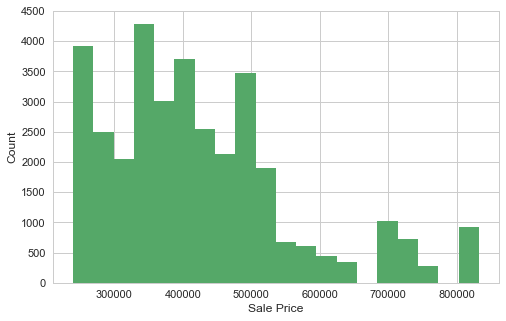

```python
sns.set(style='whitegrid', palette="deep", font_scale=1.1, rc={"figure.figsize": [8, 5]})
sns.distplot(
    data_set['price'], norm_hist=False, kde=False, bins=20, hist_kws={"alpha": 1}
).set(xlabel='Sale Price', ylabel='Count');
plt.show()
```

- Resale Price is distributed mostly in 300K to 500K SGD, with few in discrete of 500+K, 600K, 700K and 800K

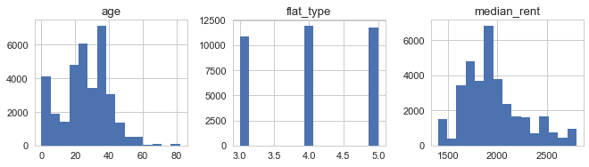

```python
data_set[['flat_type','median_rent','age']].hist(bins=15, figsize=(15, 6), layout=(2, 4))
plt.show()
```

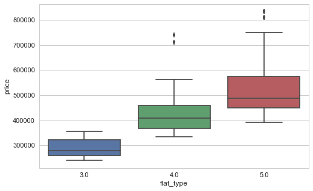

```python
sns.boxplot(x=data_set['flat_type'], y=data_set['price'])
plt.show()
```

- Price is highly correlate to flat type, as 3 Room have a price centered around 300K, 4 Room around 400K and 5 Room for 500K SGD

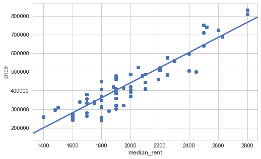

```python
sns.regplot(x=data_set['median_rent'], y=data_set['price'])
plt.show()
```

- Rent is positively propotional to Price

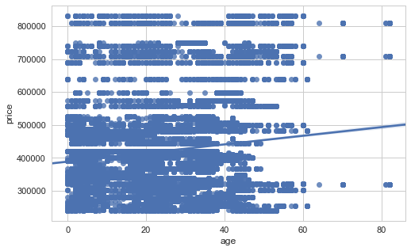

```python
sns.regplot(x=data_set['age'], y=data_set['price'])
plt.show()
```

- Price is quite independent on age of HDB housing

# Feature Selection by Lasso of L1 Loss

```python
from sklearn.model_selection import train_test_split
from sklearn.linear_model import Lasso
from sklearn.feature_selection import SelectFromModel
from sklearn.preprocessing import StandardScaler
from sklearn.linear_model import LinearRegression
from math import sqrt
```

- train test split of 7:3

```python
X_train, X_test, y_train, y_test = train_test_split(
    data_set.drop(labels=['price', 'address','town'], axis=1),
    data_set['price'],
    test_size=0.3,
    random_state=0)
X_train.shape, X_test.shape
```

```
((24187, 25), (10367, 25))
```

- Standardization and fill Nan

```python
scaler = StandardScaler()
scaler.fit(X_train.fillna(0))
```

```
StandardScaler(copy=True, with_mean=True, with_std=True)
```

- Lasso Alpha range from 0.1 to 10000

```python
Alpha=[0.1,1,10,100,1000,10000]
```

```python
feature_selected=[]
feature_names=[]
MAE=[]
RMSE=[]
R2_score=[]
```

- Use the features selected by Lasso to perform Linear regression and compare MAE,RMSE and R2 score

```python
for alpha in Alpha:

    sel_ = SelectFromModel(Lasso(alpha))
    sel_.fit(scaler.transform(X_train.fillna(0)), y_train)
    selected_feat = X_train.columns[(sel_.get_support())]
    print('Alpha:{}'.format(alpha))
    print('total features: {}'.format((X_train.shape[1])))
    print('selected features: {}'.format(len(selected_feat)))
    feature_selected.append(len(selected_feat))
    print('features with coefficients shrank to zero: {}'.format(
          np.sum(sel_.estimator_.coef_ == 0)))
    feature_names.append(selected_feat)
    X_train_selected = sel_.transform(X_train.fillna(0))
    X_test_selected = sel_.transform(X_test.fillna(0))
    regressor = LinearRegression()
    regressor.fit(X_train_selected, y_train)
    yhat = regressor.predict(X_test_selected)
    print("Mean absolute error: %.2f" % np.mean(np.absolute(yhat - y_test)))
    MAE.append("%.2f" % np.mean(np.absolute(yhat - y_test)))
    print("Root Residual sum of squares (RMSE): %.2f" % sqrt(np.mean((yhat - y_test) ** 2)))
    mse=np.mean((yhat - y_test) ** 2)
    rmse= sqrt(mse)
    RMSE.append("%.2f" % rmse)
    from sklearn.metrics import r2_score
    print("R2-score: %.2f" % r2_score(yhat,y_test) )
    R2_score.append("%.2f" % r2_score(yhat,y_test))
```

```
Alpha:0.1
total features: 25
selected features: 25
features with coefficients shrank to zero: 0
Mean absolute error: 36532.51
Root Residual sum of squares (RMSE): 45919.30
R2-score: 0.87
```

```
Alpha:1
total features: 25
selected features: 25
features with coefficients shrank to zero: 0
Mean absolute error: 36532.51
Root Residual sum of squares (RMSE): 45919.30
R2-score: 0.87
Alpha:10
total features: 25
selected features: 24
features with coefficients shrank to zero: 1
Mean absolute error: 36532.51
Root Residual sum of squares (RMSE): 45919.30
R2-score: 0.87
Alpha:100
total features: 25
selected features: 21
features with coefficients shrank to zero: 4
Mean absolute error: 36539.40
Root Residual sum of squares (RMSE): 45914.75
R2-score: 0.87
Alpha:1000
total features: 25
selected features: 8
features with coefficients shrank to zero: 17
Mean absolute error: 36604.45
Root Residual sum of squares (RMSE): 45952.70
R2-score: 0.87
Alpha:10000
total features: 25
selected features: 2
features with coefficients shrank to zero: 23
Mean absolute error: 37577.78
Root Residual sum of squares (RMSE): 46732.99
R2-score: 0.87
```

```python
pd.DataFrame(list(zip(Alpha,feature_selected,feature_names,MAE,RMSE,R2_score)),\
             columns =['Alpha','feature_selected','feature_names','MAE','RMSE','R2_score'])
```

|  | Alpha | feature_selected | feature_names | MAE | RMSE | R2_score |
| --- | --- | --- | --- | --- | --- | --- |
| 0 | 0.1 | 25 | Index(['max_floor_lvl', 'residential', 'commer... | 36532.51 | 45919.30 | 0.87 |
| 1 | 1.0 | 25 | Index(['max_floor_lvl', 'residential', 'commer... | 36532.51 | 45919.30 | 0.87 |
| 2 | 10.0 | 24 | Index(['max_floor_lvl', 'residential', 'commer... | 36532.51 | 45919.30 | 0.87 |
| 3 | 100.0 | 21 | Index(['max_floor_lvl', 'commercial', 'market_... | 36539.40 | 45914.75 | 0.87 |
| 4 | 1000.0 | 8 | Index(['max_floor_lvl', 'commercial', 'market_... | 36604.45 | 45952.70 | 0.87 |
| 5 | 10000.0 | 2 | Index(['flat_type', 'median_rent'], dtype='obj... | 37577.78 | 46732.99 | 0.87 |

- To prevent overfitting, we will select flat_type and median_rent, which will give decent R2 and similar MAE and RMSE

```python
X_explore=to_explore.drop(labels=['price', 'address','town'], axis=1)
pred=regressor.predict(sel_.transform(X_explore.fillna(0)))
```

```python
regressor.coef_
```

```
array([ 38161.94771788,    340.5834673 ])
```

```python
regressor.intercept_
```

```
-396247.97384577146
```

```python
pred
```

```
array([ 459314.29540396,  459314.29540396,  459314.29540396, ...,
        425255.94867347,  425255.94867347,  425255.94867347])
```

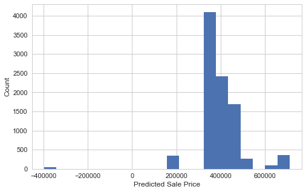

```python
sns.set(style='whitegrid', palette="deep", font_scale=1.1, rc={"figure.figsize": [8, 5]})
sns.distplot(
    pred, norm_hist=False, kde=False, bins=20, hist_kws={"alpha": 1}
).set(xlabel='Predicted Sale Price', ylabel='Count');
plt.show()
```

```python
pred.shape
```

```
(9303,)
```